# DDS Case Study 2

## Feature Modeling

Now we will try to determine which variables are the most influential for employee attrition and salary.

### Relationship Between Response Variables

We have 2 response variables to examine: * Attrition: binomial / categorical [i.e. “yes” or “no”] * MonthlyIncome: numerical salary by month

First we use a boxplot to compare the MonthlyIncome distribution for “Yes” vs “No” Attrition groups. We an certainly see that visually the distributions appear to be different from each other.

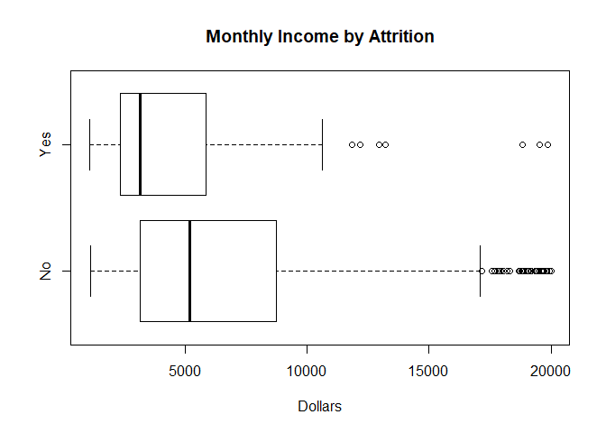

```r
# Comparing MonthlyIncome by different Attrition levels
boxplot(emp_clean.df$MonthlyIncome ~ emp_clean.df$Attrition,
        main = "Monthly Income by Attrition",
        horizontal = T,
        xlab = "Dollars" )
```

We split the income values into separate vectors and run some exploratory analysis on them. We see that there are about 5 times as many employees who stay vs those who leave. It also appears the mean MonthlyIncome for employees who leave is somewhat lower:

- $4764.79 for empoyees who leave
- $6702 for those that stay

There is also greater variance in between the two groups as well: * The “Yes” group having a standard deviation of $3786.389 * The “No” group having a standard deviation of $4675.472

```r
# make vectors for monthly income by attrition
emp_clean.df$MonthlyIncome[emp_clean.df$Attrition == "Yes"] -> mo_income_yes
emp_clean.df$MonthlyIncome[emp_clean.df$Attrition == "No"] -> mo_income_no

# number of yes vs no attrition
length(mo_income_yes)
```

```
## [1] 140
```

```r
length(mo_income_no)
```

```
## [1] 730
```

```r
summary(mo_income_yes)
```

```
##    Min. 1st Qu.  Median    Mean 3rd Qu.    Max.
##    1081    2342    3171    4765    5839   19859
```

```r
summary(mo_income_no)
```

```
##    Min. 1st Qu.  Median    Mean 3rd Qu.    Max.
##    1129    3162    5208    6702    8736   19999
```

```r
sd(mo_income_yes)
```

```
## [1] 3786.389
```

```r
sd(mo_income_no)
```

```
## [1] 4675.472
```

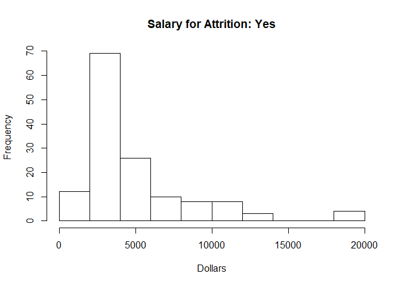

```r
# histogram of each
hist(mo_income_yes, xlab = "Dollars", main = "Salary for Attrition: Yes")
```

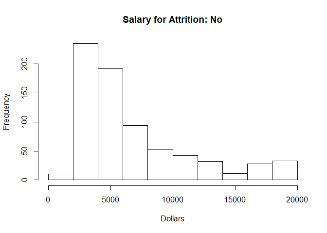

```r
hist(mo_income_no, xlab = "Dollars", main = "Salary for Attrition: No")
```

Because both distrubitions differ significantly from normality we log tranform them in order to do a t-test and see if there is evidence that the distributions differ significantly from each other.

The QQ Plot of the log transformed MonthlyIncome for each group shows much better adherence to normality, and brings the variance of each group much closer together.

The T-test itself shows there is a significant difference between the Monthly Incomes of “Yes” vs “No” attrition groups, p-value < 0.0001. This is strong evidence that MonthlyIncome has an effect on Attrition

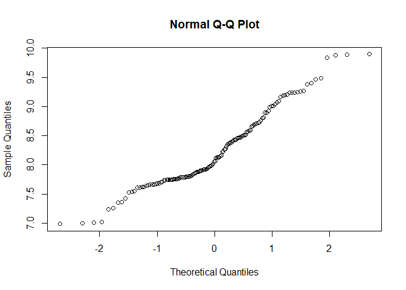

```r
### T-test to compare each group

# taking log of each
qqnorm(log(mo_income_yes))
```

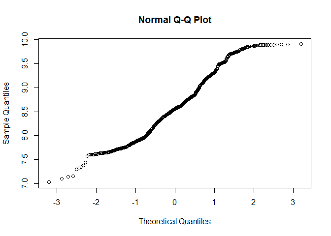

```r
qqnorm(log(mo_income_no))
```

```r
# even using the log of both still get
# to be safe we account for unequal variance
t.test(log(mo_income_no), log(mo_income_yes), var.equal = F)
```

```
##
##  Welch Two Sample t-test
##
## data:  log(mo_income_no) and log(mo_income_yes)
## t = 5.9593, df = 195.72, p-value = 1.16e-08
## alternative hypothesis: true difference in means is not equal to 0
## 95 percent confidence interval:
##  0.2391013 0.4756331
## sample estimates:
## mean of x mean of y
##  8.595187  8.237820
```

## Random Forest for Influential Factors

We still have the challenge of 25 parameters to determine MonthlyIncome, and 26 parameters [including MonthlyIncome] to predict Attrition.

Here we are going to use Random Forest to help see which of these are the most influential and cross-reference against common industry expertise. It is essentially a collection or “ensemble”" of individual decision trees, by first generating a random sample of the original data with replacement, aka “bootstrapping.” Multiple subsets of trees are built using a randomly select set of our data set’s variables.

The variable importance plot tells us how important each variable is in classifying the data. The plot on the left “Mean Decrease in Accuracy” is the one we will be focusing on. Essentially translates that the more important the parameter, the less accurate the random forest model becomes when it is omitted.

*Attrition*

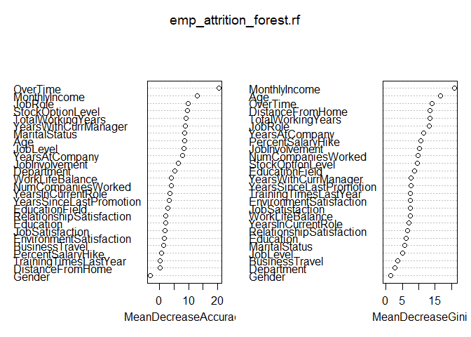

```r
# excluding redundant AnnualIncome
emp_clean.df[,-c(28)] -> emp_attrition_forest.df

# Random forest for Attrition
emp_attrition_forest.rf <- randomForest(Attrition ~.,
                                     data = emp_attrition_forest.df,
                                     importance = TRUE)
varImpPlot(emp_attrition_forest.rf)
```

### Deeper look at OverTime

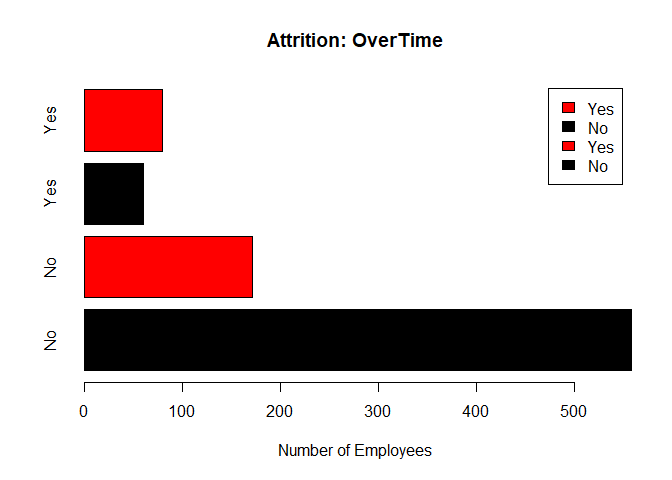

```r
barplot(
  emp_clean_factor.df %>% group_by(Attrition) %>% count(OverTime) %>% .[[3]],
  col = emp_clean_factor.df %>% group_by(Attrition) %>% count(OverTime) %>% .[[2]],
  names.arg = emp_clean_factor.df %>% group_by(Attrition) %>% count(OverTime) %>% .[[1]],
  legend.text = emp_clean_factor.df %>% group_by(Attrition) %>% count(OverTime) %>% .[[2]],
  horiz = T,
  xlab = "Number of Employees",
  main = "Attrition: OverTime"
)
```

### Deeper look at AnnualIncome

Again the ratio of employees that leave is higher depending on what level they are in AnnualIncome category:

- Under_30k: 96 stay vs 49 leave
- 30k_to_60k: 248 stay vs 50 leave
- 60k_to_90k: 175 stay vs 16 leave
- Over_90k: 211 stay vs 25 leave

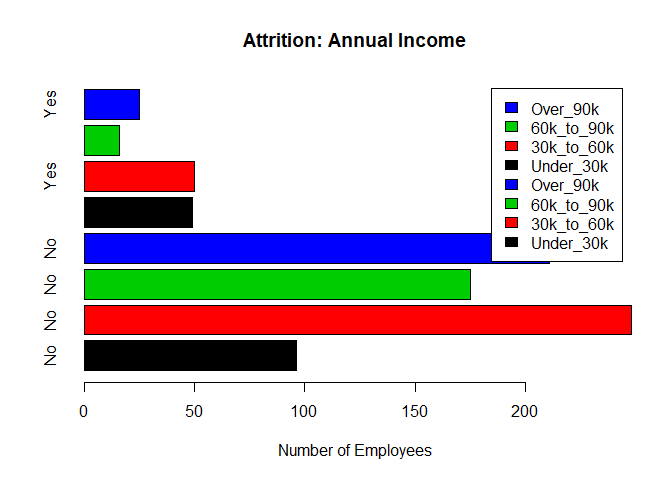

```r
barplot(
  emp_clean_factor.df %>% group_by(Attrition) %>% count(AnnualIncome) %>% .[[3]],
  col = emp_clean_factor.df %>% group_by(Attrition) %>% count(AnnualIncome) %>% .[[2]],
  names.arg = emp_clean_factor.df %>% group_by(Attrition) %>% count(AnnualIncome) %>% .[[1]],
  legend.text = emp_clean_factor.df %>% group_by(Attrition) %>% count(AnnualIncome) %>% .[[2]],
  horiz = T,
  xlab = "Number of Employees",
  main = "Attrition: Annual Income"
)
```

### Deeper look at JobRole

Certain job roles have a different attrition ratio. Sales Reps is almost a 1 for 1 with 29 stay vs 24 leave. On the other end Research Directors and Manufacturing Directors have the lowest attrition [50 vs 1] and [85 vs 2] respectively.

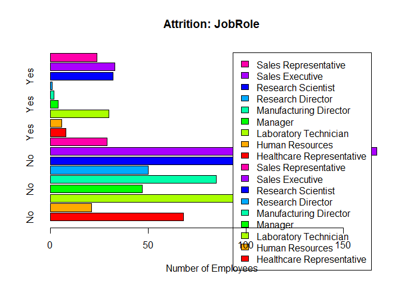

```r
barplot(
  emp_clean_factor.df %>% group_by(Attrition) %>% count(JobRole) %>% .[[3]],
  col = rainbow(9),
  names.arg = emp_clean_factor.df %>% group_by(Attrition) %>% count(JobRole) %>% .[[1]],
  legend.text = emp_clean_factor.df %>% group_by(Attrition) %>% count(JobRole) %>% .[[2]],
  horiz = T,
  xlab = "Number of Employees",
  main = "Attrition: JobRole"
)
```

*MonthlyIncome* Top 5 most influential were:

- JobLevel
- JobRole
- TotalWorkingYears
- YearsAtCompany
- Age

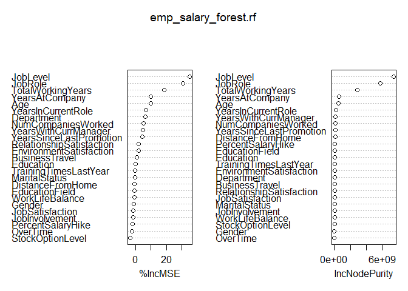

```r
# excluding redundant AnnualIncome and Attrition
emp_clean.df[,-c(2,28)] -> emp_salary_forest.df

# Random forest for MonthlyIncome
emp_salary_forest.rf <- randomForest(MonthlyIncome ~.,
                                     data = emp_salary_forest.df,
                                     importance = TRUE)
varImpPlot(emp_salary_forest.rf)
```

## Monthly Income

### Correlation in Numeric Variables

```r
# creating function for heatmap using corrplot::corrplot()

correlator  <-  function(df){
  df %>%
    keep(is.numeric) %>%
    tidyr::drop_na() %>%
    cor %>%
    corrplot( addCoef.col = "white", number.digits = 2,
              number.cex = 0.5, method="square",
              order="hclust", title="Variable Corr Heatmap",
              tl.srt=45, tl.cex = 0.8)
}
```

### Closer Look At Job Level

A closer examination supports evidence of a relationship between MonthlyIncome and JobLevel

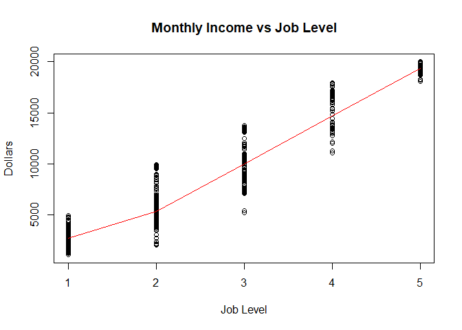

```r
# monthly income by job level
plot(emp_clean.df$JobLevel, emp_clean.df$MonthlyIncome, main = "Monthly Income vs Job Level",
     xlab = "Job Level",
     ylab = "Dollars")
lines(lowess(emp_clean.df$JobLevel, emp_clean.df$MonthlyIncome), col = "red")
```

### Closer Look At Total Working Years

A closer examination supports evidence of a relationship between MonthlyIncome and TotalWorkingYears

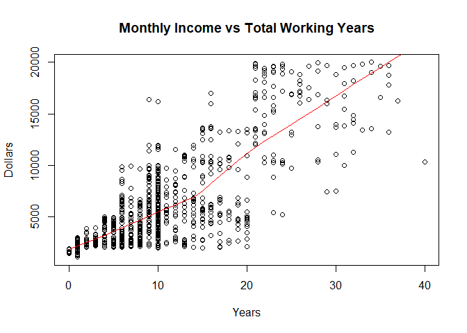

```r
# monthly income total working years
plot(emp_clean.df$TotalWorkingYears, emp_clean.df$MonthlyIncome, main = "Monthly Income vs Total Working Years",
     xlab = "Years",
     ylab = "Dollars")
lines(lowess(emp_clean.df$TotalWorkingYears, emp_clean.df$MonthlyIncome), col = "red")
```

### Linear Regression Model: MonthlyIncome

However we need to be congnizant of covariance. When we examine our model we notice that JobRole and Department have extremely high VIF. Typically a VIF value should never be larger than 10.

In light of this we will update our model

```r
### Linear Regression on MonthlyIncome

#NOTE: Re-using Random Forest DF that excluded Attrition and AnnualIncome
emp_salary_forest.df -> emp_salary_reg.df
# First create model on all variables
lm(MonthlyIncome ~ ., data =  emp_salary_reg.df) -> emp_salary.lm
summary(emp_salary.lm)
```

```
##
## Call:
## lm(formula = MonthlyIncome ~ ., data = emp_salary_reg.df)
##
## Residuals:
##     Min      1Q  Median      3Q     Max
## -3737.2  -656.2   -33.6   589.1  4136.7
##
## Coefficients:
##                                  Estimate Std. Error t value Pr(>|t|)
## (Intercept)                      -606.140    668.262  -0.907 0.364649
## Age                                -1.639      5.654  -0.290 0.771955
## BusinessTravelTravel_Frequently   182.855    141.863   1.289 0.197775
## BusinessTravelTravel_Rarely       369.777    120.413   3.071 0.002204 **
## DepartmentResearch & Development  114.497    478.229   0.239 0.810839
## DepartmentSales                  -430.542    489.251  -0.880 0.379113
## DistanceFromHome                   -6.311      4.559  -1.384 0.166647
## Education                         -30.058     37.243  -0.807 0.419856
## EducationFieldLife Sciences       131.421    369.673   0.356 0.722301
## EducationFieldMarketing           106.003    391.782   0.271 0.786792
## EducationFieldMedical              26.071    370.560   0.070 0.943927
## EducationFieldOther                84.344    395.567   0.213 0.831205
## EducationFieldTechnical Degree     87.267    385.419   0.226 0.820930
## EnvironmentSatisfaction           -10.055     33.561  -0.300 0.764551
## GenderMale                        119.237     74.663   1.597 0.110648
## JobInvolvement                     17.245     52.444   0.329 0.742365
## JobLevel                         2798.801     83.435  33.544  < 2e-16 ***
## JobRoleHuman Resources           -191.727    516.673  -0.371 0.710673
## JobRoleLaboratory Technician     -603.937    171.759  -3.516 0.000462 ***
## JobRoleManager                   4199.953    282.586  14.863  < 2e-16 ***
## JobRoleManufacturing Director     153.533    170.023   0.903 0.366782
## JobRoleResearch Director         4012.539    219.451  18.284  < 2e-16 ***
## JobRoleResearch Scientist        -331.361    170.699  -1.941 0.052572 .
## JobRoleSales Executive            487.672    358.943   1.359 0.174632
## JobRoleSales Representative       109.404    392.699   0.279 0.780625
## JobSatisfaction                    23.515     32.974   0.713 0.475958
## MaritalStatusMarried               70.239    100.024   0.702 0.482740
## MaritalStatusSingle                16.787    134.568   0.125 0.900753
## NumCompaniesWorked                  8.757     16.798   0.521 0.602279
## OverTimeYes                         7.519     81.140   0.093 0.926191
## PercentSalaryHike                   1.193      9.961   0.120 0.904732
## RelationshipSatisfaction           16.304     33.297   0.490 0.624510
## StockOptionLevel                    6.157     56.901   0.108 0.913859
## TotalWorkingYears                  49.926     10.999   4.539 6.48e-06 ***
## TrainingTimesLastYear              23.730     29.182   0.813 0.416350
## WorkLifeBalance                   -43.459     51.593  -0.842 0.399844
## YearsAtCompany                     -2.131     13.620  -0.156 0.875706
## YearsInCurrentRole                  3.479     17.006   0.205 0.837942
## YearsSinceLastPromotion            29.344     15.258   1.923 0.054804 .
## YearsWithCurrManager              -26.775     16.731  -1.600 0.109901
## ---
## Signif. codes:  0 '***' 0.001 '**' 0.01 '*' 0.05 '.' 0.1 ' ' 1
##
## Residual standard error: 1061 on 830 degrees of freedom
## Multiple R-squared:  0.9491, Adjusted R-squared:  0.9468
## F-statistic: 397.2 on 39 and 830 DF,  p-value: < 2.2e-16
```

```r
# Then test for VIF
vif(emp_salary.lm)
```

```
##                                GVIF Df GVIF^(1/(2*Df))
## Age                        1.966832  1        1.402438
## BusinessTravel             1.110032  2        1.026441
## Department               110.874985  2        3.244953
## DistanceFromHome           1.062561  1        1.030806
## Education                  1.120870  1        1.058711
## EducationField             2.898610  5        1.112292
## EnvironmentSatisfaction    1.051126  1        1.025244
## Gender                     1.039965  1        1.019787
## JobInvolvement             1.051408  1        1.025382
## JobLevel                   6.387536  1        2.527358
## JobRole                  494.745698  8        1.473665
## JobSatisfaction            1.042825  1        1.021188
## MaritalStatus              1.984091  2        1.186835
## NumCompaniesWorked         1.384089  1        1.176473
## OverTime                   1.047147  1        1.023302
## PercentSalaryHike          1.034879  1        1.017290
## RelationshipSatisfaction   1.040543  1        1.020070
## StockOptionLevel           1.839351  1        1.356227
## TotalWorkingYears          5.273175  1        2.296339
## TrainingTimesLastYear      1.064991  1        1.031984
## WorkLifeBalance            1.041859  1        1.020715
## YearsAtCompany             5.192457  1        2.278696
## YearsInCurrentRole         2.957481  1        1.719733
## YearsSinceLastPromotion    1.824576  1        1.350768
## YearsWithCurrManager       2.761474  1        1.661768
```

Given that TotalWorkingYears is one of the critical parameters identified by the model, we will leave it in for now and remove only YearsAtCompany

We can see now that all parameters have a VIF lower than 5

```r
# Rerun with JobRole and Department removed
emp_salary_reg.df[,-c(4,12,23)] -> emp_salary_reg.df
# create model on remaining variables
lm(MonthlyIncome ~ ., data =  emp_salary_reg.df) -> emp_salary.lm
summary(emp_salary.lm)
```

```
##
## Call:
## lm(formula = MonthlyIncome ~ ., data = emp_salary_reg.df)
##
## Residuals:
##     Min      1Q  Median      3Q     Max
## -5861.0  -769.5    -6.5   742.5  4301.9
##
## Coefficients:
##                                  Estimate Std. Error t value Pr(>|t|)
## (Intercept)                     -1806.637    619.214  -2.918  0.00362 **
## Age                                -2.169      7.224  -0.300  0.76405
## BusinessTravelTravel_Frequently    11.756    181.331   0.065  0.94833
## BusinessTravelTravel_Rarely       320.527    154.247   2.078  0.03801 *
## DistanceFromHome                  -15.666      5.845  -2.680  0.00750 **
## Education                          16.011     47.516   0.337  0.73624
## EducationFieldLife Sciences      -300.034    364.462  -0.823  0.41061
## EducationFieldMarketing          -662.914    383.450  -1.729  0.08421 .
## EducationFieldMedical            -263.247    367.030  -0.717  0.47343
## EducationFieldOther              -373.388    404.501  -0.923  0.35623
## EducationFieldTechnical Degree   -299.439    390.652  -0.767  0.44359
## EnvironmentSatisfaction           -64.413     42.860  -1.503  0.13325
## GenderMale                         75.961     95.906   0.792  0.42856
## JobInvolvement                     95.049     66.825   1.422  0.15529
## JobLevel                         3745.200     69.721  53.717  < 2e-16 ***
## JobSatisfaction                    -4.059     42.325  -0.096  0.92362
## MaritalStatusMarried              150.965    128.169   1.178  0.23919
## MaritalStatusSingle                -6.329    171.898  -0.037  0.97064
## NumCompaniesWorked                 -8.432     20.860  -0.404  0.68615
## OverTimeYes                        25.636    103.697   0.247  0.80480
## PercentSalaryHike                   9.370     12.802   0.732  0.46445
## RelationshipSatisfaction           23.958     42.861   0.559  0.57633
## StockOptionLevel                   -9.418     72.987  -0.129  0.89736
## TotalWorkingYears                  68.280     13.201   5.172 2.89e-07 ***
## TrainingTimesLastYear              20.487     37.236   0.550  0.58232
## WorkLifeBalance                   -27.215     66.220  -0.411  0.68119
## YearsInCurrentRole                -16.614     19.871  -0.836  0.40335
## YearsSinceLastPromotion             3.586     18.654   0.192  0.84759
## YearsWithCurrManager              -50.185     19.476  -2.577  0.01014 *
## ---
## Signif. codes:  0 '***' 0.001 '**' 0.01 '*' 0.05 '.' 0.1 ' ' 1
##
## Residual standard error: 1369 on 841 degrees of freedom
## Multiple R-squared:  0.9141, Adjusted R-squared:  0.9113
## F-statistic: 319.8 on 28 and 841 DF,  p-value: < 2.2e-16
```

```r
# Then test for VIF
vif(emp_salary.lm)
```

```
##                              GVIF Df GVIF^(1/(2*Df))
## Age                      1.926750  1        1.388074
## BusinessTravel           1.071485  2        1.017411
## DistanceFromHome         1.048116  1        1.023775
## Education                1.094953  1        1.046400
## EducationField           1.149730  5        1.014051
## EnvironmentSatisfaction  1.028756  1        1.014276
## Gender                   1.029742  1        1.014762
## JobInvolvement           1.024454  1        1.012153
## JobLevel                 2.676686  1        1.636058
## JobSatisfaction          1.031099  1        1.015431
## MaritalStatus            1.930257  2        1.178701
## NumCompaniesWorked       1.280881  1        1.131760
## OverTime                 1.026384  1        1.013106
## PercentSalaryHike        1.025949  1        1.012891
## RelationshipSatisfaction 1.034677  1        1.017191
## StockOptionLevel         1.816129  1        1.347638
## TotalWorkingYears        4.558435  1        2.135049
## TrainingTimesLastYear    1.040561  1        1.020079
## WorkLifeBalance          1.029981  1        1.014880
## YearsInCurrentRole       2.423289  1        1.556692
## YearsSinceLastPromotion  1.636534  1        1.279271
## YearsWithCurrManager     2.245623  1        1.498540
```

### Stepwise Selection

Important Factors that all have p-value <= 0.05:

- BusinessTravel: Travel_Rarely
- DistanceFromHome
- EducationField: Marketing
- JobLevel
- TotalWorkingYears
- YearsWithCurrManager

And the Adjusted R-squared is 0.9128, which means an estimated 91.28% of the MonthlyIncome variable can be accounted for by this model.

```r
# set method to use 5-fold cross-validation
trainControl(method = "cv", number = 5) -> train.cv

train(MonthlyIncome ~ .,
  data = emp_salary_reg.df,
  method = "lmStepAIC",
  trControl = train.cv
) -> emp_salary.step
```

[output not shown]

[output cut: 3626 more lines]

```
## .outcome ~ BusinessTravelTravel_Rarely + DistanceFromHome + EducationFieldMarketing +
##     EnvironmentSatisfaction + JobInvolvement + JobLevel + MaritalStatusMarried +
##     TotalWorkingYears + YearsWithCurrManager
##
##                               Df  Sum of Sq        RSS   AIC
## <none>                                      1585015846 12561
## - JobInvolvement               1    3932348 1588948194 12562
## - MaritalStatusMarried         1    3970026 1588985873 12562
## - EnvironmentSatisfaction      1    4979154 1589995000 12562
## - DistanceFromHome             1   12838996 1597854842 12566
## - EducationFieldMarketing      1   12878775 1597894622 12566
## - BusinessTravelTravel_Rarely  1   16737293 1601753139 12568
## - YearsWithCurrManager         1   29408237 1614424083 12575
## - TotalWorkingYears            1   70832125 1655847971 12597
## - JobLevel                     1 5548821138 7133836984 13868
```

```r
# Final model
summary(emp_salary.step)
```

```
##
## Call:
## lm(formula = .outcome ~ BusinessTravelTravel_Rarely + DistanceFromHome +
##     EducationFieldMarketing + EnvironmentSatisfaction + JobInvolvement +
##     JobLevel + MaritalStatusMarried + TotalWorkingYears + YearsWithCurrManager,
##     data = dat)
##
## Residuals:
##     Min      1Q  Median      3Q     Max
## -5857.8  -761.3     0.4   735.0  4244.8
##
## Coefficients:
##                              Estimate Std. Error t value Pr(>|t|)
## (Intercept)                 -1887.027    253.357  -7.448 2.30e-13 ***
## BusinessTravelTravel_Rarely   308.194    102.270   3.014  0.00266 **
## DistanceFromHome              -15.086      5.716  -2.639  0.00846 **
## EducationFieldMarketing      -385.885    145.978  -2.643  0.00836 **
## EnvironmentSatisfaction       -68.977     41.965  -1.644  0.10061
## JobInvolvement                 95.713     65.526   1.461  0.14447
## JobLevel                     3745.203     68.256  54.870  < 2e-16 ***
## MaritalStatusMarried          137.169     93.461   1.468  0.14256
## TotalWorkingYears              64.114     10.342   6.199 8.79e-10 ***
## YearsWithCurrManager          -58.150     14.557  -3.995 7.04e-05 ***
## ---
## Signif. codes:  0 '***' 0.001 '**' 0.01 '*' 0.05 '.' 0.1 ' ' 1
##
## Residual standard error: 1358 on 860 degrees of freedom
## Multiple R-squared:  0.9137, Adjusted R-squared:  0.9128
## F-statistic:  1012 on 9 and 860 DF,  p-value: < 2.2e-16
```

```r
# Results including RMSE of final model
emp_salary.step$results
```

```
##   parameter    RMSE  Rsquared      MAE   RMSESD  RsquaredSD    MAESD
## 1      none 1379.66 0.9101195 1034.596 54.37536 0.005402434 44.15991
```

### Comparison to Random Forest

```r
# Compare to Randome Forest
# emp_salary_reg.df[,-c(4,12)] -> emp_salary_reg.df

train(MonthlyIncome ~ JobLevel + JobRole + TotalWorkingYears + YearsAtCompany + Age,
  data = emp_clean.df,
  method = "lm",
  trControl = train.cv
) -> emp_salary_rf.step

# Final model
summary(emp_salary_rf.step)
```

```
##
## Call:
## lm(formula = .outcome ~ ., data = dat)
##
## Residuals:
##     Min      1Q  Median      3Q     Max
## -3947.4  -637.6   -21.3   604.0  4122.0
##
## Coefficients:
##                                 Estimate Std. Error t value Pr(>|t|)
## (Intercept)                      -67.470    263.485  -0.256  0.79796
## JobLevel                        2800.149     82.407  33.979  < 2e-16 ***
## `JobRoleHuman Resources`        -317.625    252.023  -1.260  0.20790
## `JobRoleLaboratory Technician`  -595.611    169.362  -3.517  0.00046 ***
## JobRoleManager                  3991.649    229.479  17.394  < 2e-16 ***
## `JobRoleManufacturing Director`  136.295    167.359   0.814  0.41565
## `JobRoleResearch Director`      3973.272    216.235  18.375  < 2e-16 ***
## `JobRoleResearch Scientist`     -322.429    169.632  -1.901  0.05767 .
## `JobRoleSales Executive`         -65.567    144.365  -0.454  0.64982
## `JobRoleSales Representative`   -413.192    212.294  -1.946  0.05194 .
## TotalWorkingYears                 51.888     10.345   5.016 6.42e-07 ***
## YearsAtCompany                    -6.050      8.052  -0.751  0.45267
## Age                               -1.231      5.496  -0.224  0.82282
## ---
## Signif. codes:  0 '***' 0.001 '**' 0.01 '*' 0.05 '.' 0.1 ' ' 1
##
## Residual standard error: 1064 on 857 degrees of freedom
## Multiple R-squared:  0.9472, Adjusted R-squared:  0.9465
## F-statistic:  1282 on 12 and 857 DF,  p-value: < 2.2e-16
```

```r
# Results including RMSE of final model
emp_salary_rf.step$results
```

```
##   intercept    RMSE Rsquared      MAE   RMSESD RsquaredSD    MAESD
## 1      TRUE 1075.59 0.945446 822.5236 51.53372 0.00643905 23.17155
```

### MonthlyIncome Predictions

*Training Data*

We can see prediction error for Random Forest, 0.1652, vs the Linear Regression, 0.2112. Thus we will use the RF model on our final data

```r
# generating predictions on test data
employee.df$MonthlyIncome_LM <- predict(emp_salary.step, newdata = employee.df)
employee.df$MonthlyIncome_RF <- predict(emp_salary_rf.step, newdata = employee.df)

# Prediction Error for Linear Regression
RMSE(employee.df$MonthlyIncome_LM, employee.df$MonthlyIncome) / mean(employee.df$MonthlyIncome)
```

```
## [1] 0.2112216
```

```r
# Prediction Error for Linear Regression
RMSE(employee.df$MonthlyIncome_RF, employee.df$MonthlyIncome) / mean(employee.df$MonthlyIncome)
```

```
## [1] 0.1651993
```

*Test Data*

We run the model on the test data sets that do not have the MonthlyIncome parameter

NOTE: Was not sure if I need to include BOTH the Regression and Random Forest predictions since homework doc said “You MUST use linear regression but MAY include additional models.” So just to be safe I’m including both:

- MonthlyIncome_LM = Predictions for Regression
- MonthlyIncome_RF = Predictions for Random Forest

```r
# loading prediction data
salary_pred.df <- read.csv(
  "https://raw.githubusercontent.com/jotsap/CaseStudy2DDS/master/data/CaseStudy2CompSet_NoSalary.csv",
  sep = ",",
  header = TRUE)
str(salary_pred.df)
```

```
## 'data.frame':    300 obs. of  35 variables:
##  $ ID                      : int  871 872 873 874 875 876 877 878 879 880 ...
##  $ Age                     : int  43 33 55 36 27 39 33 21 30 51 ...
##  $ Attrition               : Factor w/ 2 levels "No","Yes": 1 1 2 1 1 2 1 2 1 1 ...
##  $ BusinessTravel          : Factor w/ 3 levels "Non-Travel","Travel_Frequently",..: 2 3 3 1 3 3 1 2 2 3 ...
##  $ DailyRate               : int  1422 461 267 1351 1302 895 750 251 1312 1405 ...
##  $ Department              : Factor w/ 3 levels "Human Resources",..: 3 2 3 2 2 3 3 2 2 2 ...
##  $ DistanceFromHome        : int  2 13 13 9 19 5 22 10 23 11 ...
##  $ Education               : int  4 1 4 4 3 3 2 2 3 2 ...
##  $ EducationField          : Factor w/ 6 levels "Human Resources",..: 2 2 3 2 5 6 3 2 2 6 ...
##  $ EmployeeCount           : int  1 1 1 1 1 1 1 1 1 1 ...
##  $ EmployeeNumber          : int  1849 995 1372 1949 1619 42 160 1279 159 1367 ...
##  $ EnvironmentSatisfaction : int  1 2 1 1 4 4 3 1 1 4 ...
##  $ Gender                  : Factor w/ 2 levels "Female","Male": 2 1 2 2 2 2 2 1 2 1 ...
##  $ HourlyRate              : int  92 53 85 66 67 56 95 45 96 82 ...
```

[output cut: 21 more lines]

```r
head(salary_pred.df)
```

```
##    ID Age Attrition    BusinessTravel DailyRate             Department
## 1 871  43        No Travel_Frequently      1422                  Sales
## 2 872  33        No     Travel_Rarely       461 Research & Development
## 3 873  55       Yes     Travel_Rarely       267                  Sales
## 4 874  36        No        Non-Travel      1351 Research & Development
## 5 875  27        No     Travel_Rarely      1302 Research & Development
## 6 876  39       Yes     Travel_Rarely       895                  Sales
##   DistanceFromHome Education   EducationField EmployeeCount EmployeeNumber
## 1                2         4    Life Sciences             1           1849
## 2               13         1    Life Sciences             1            995
## 3               13         4        Marketing             1           1372
## 4                9         4    Life Sciences             1           1949
## 5               19         3            Other             1           1619
## 6                5         3 Technical Degree             1             42
##   EnvironmentSatisfaction Gender HourlyRate JobInvolvement JobLevel
```

[output cut: 41 more lines]

```r
# generating predictions on test data
salary_pred.df$MonthlyIncome_LM <- predict(emp_salary.step, newdata = salary_pred.df)
salary_pred.df$MonthlyIncome_RF <- predict(emp_salary_rf.step, newdata = salary_pred.df)
```

## Attrition

Now we will focus on Attrition, first using K-Nearest Neighbor [KNN], and then comparing to a Random Forest model

First we need to split the data into a training & testing set. 80% of our data will be used for the training set and will be used to create the model. The remaining 20% is for the test set, which will be used to validate actual values vs predicted values using our model.

We need to measure the models:

- Accuracy: correct results / all results
- Sensitivity: correctly predicted Attrition:No / All actual “No”
- Specificity: correctly predicted Attrition:Yes / All actual “Yes”

```r
### Creating 80/20 Training / Test Data Split

attrition.vector <- createDataPartition(emp_attrition_forest.df$Attrition, p = 0.8, list = F)
attrition.train <- emp_attrition_forest.df[attrition.vector,]
attrition.test <- emp_attrition_forest.df[-attrition.vector,]

# validate train and test sets
head(attrition.train)
```

```
##   MonthlyIncome Attrition Age    BusinessTravel             Department
## 1          4403        No  32     Travel_Rarely                  Sales
## 2         19626        No  40     Travel_Rarely Research & Development
## 3          9362        No  35 Travel_Frequently Research & Development
## 4         10422        No  32     Travel_Rarely                  Sales
## 5          3760        No  24 Travel_Frequently Research & Development
## 7          2127        No  41     Travel_Rarely Research & Development
##   DistanceFromHome Education   EducationField EnvironmentSatisfaction
## 1               13         4    Life Sciences                       2
## 2               14         3          Medical                       3
## 3               18         2    Life Sciences                       3
## 4                1         4        Marketing                       3
## 5                2         1 Technical Degree                       1
## 7                5         5          Medical                       2
##   Gender JobInvolvement JobLevel                JobRole JobSatisfaction
```

[output cut: 34 more lines]

```r
head(attrition.test)
```

```
##    MonthlyIncome Attrition Age    BusinessTravel             Department
## 6           8793        No  27 Travel_Frequently Research & Development
## 12          2706        No  28        Non-Travel        Human Resources
## 14          2476        No  30     Travel_Rarely                  Sales
## 16          6932        No  31        Non-Travel                  Sales
## 19          2932        No  34     Travel_Rarely Research & Development
## 22          8120        No  48     Travel_Rarely                  Sales
##    DistanceFromHome Education   EducationField EnvironmentSatisfaction
## 6                10         2    Life Sciences                       4
## 12                1         2    Life Sciences                       3
## 14                2         1 Technical Degree                       3
## 16               20         2        Marketing                       4
## 19                2         4          Medical                       4
## 22                2         1        Marketing                       2
##    Gender JobInvolvement JobLevel                JobRole JobSatisfaction
```

[output cut: 34 more lines]

### K-Nearest Neighbor

```
   No Yes
```

```r
# control settings for KNN
# NOTE: needed in order to focus on specificity

train.knn <- trainControl(
  method = "repeatedcv",
  number = 5,
  repeats = 25,
  summaryFunction = twoClassSummary,
  classProbs = TRUE
)

# KNN on Training Set

attrition.knn <- train(
  Attrition ~ .,
  data = attrition.train,
  method = "knn",
  metric = "Spec",
  trControl = train.knn,
  preProcess = c("center","scale"),
  tuneLength = 6
)

# Adding predictions to Test Data
predict(attrition.knn, newdata = attrition.test ) -> attrition.test$Attrition_KNN
# creating confusion matrix
confusionMatrix(
  table(attrition.test$Attrition, attrition.test$Attrition_KNN )
)
```

```
## Confusion Matrix and Statistics
##
##
##        No Yes
##   No  142   4
##   Yes  23   5
##
##                Accuracy : 0.8448
##                  95% CI : (0.7823, 0.8952)
##     No Information Rate : 0.9483
##     P-Value [Acc > NIR] : 1.000000
##
##                   Kappa : 0.2083
##  Mcnemar's Test P-Value : 0.000532
##
##             Sensitivity : 0.8606
##             Specificity : 0.5556
##          Pos Pred Value : 0.9726
##          Neg Pred Value : 0.1786
##              Prevalence : 0.9483
##          Detection Rate : 0.8161
##    Detection Prevalence : 0.8391
##       Balanced Accuracy : 0.7081
##
##        'Positive' Class : No
##
```

### Random Forest

```
  No Yes
```

```r
# Random Forest
train(Attrition ~ .,
  data = attrition.train,
  method = "rf",
  trControl = train.cv,
  importance = TRUE
) -> attrition.rf

# Adding predictions to Test Data
predict(attrition.rf, newdata = attrition.test ) -> attrition.test$Attrition_RF
# creating confusion matrix
confusionMatrix(
  table(attrition.test$Attrition, attrition.test$Attrition_RF )
)
```

```
## Confusion Matrix and Statistics
##
##
##        No Yes
##   No  143   3
##   Yes  19   9
##
##                Accuracy : 0.8736
##                  95% CI : (0.8149, 0.919)
##     No Information Rate : 0.931
##     P-Value [Acc > NIR] : 0.997903
##
##                   Kappa : 0.3912
##  Mcnemar's Test P-Value : 0.001384
##
##             Sensitivity : 0.8827
##             Specificity : 0.7500
##          Pos Pred Value : 0.9795
##          Neg Pred Value : 0.3214
##              Prevalence : 0.9310
##          Detection Rate : 0.8218
##    Detection Prevalence : 0.8391
##       Balanced Accuracy : 0.8164
##
##        'Positive' Class : No
##
```

### Predictions for Attrition

As an additional validation step we then can run the two models across the entire data set and compare against the actual Attrition values

*Validating KNN on Entire Training Data Set*

Again the model performs will acheiving over 85% in all 3 categories

```
   No Yes
```

```r
# generating predictions on test data
employee.df$Attrition_KNN <- predict(attrition.knn, newdata = employee.df)

# creating confusion matrix for KNN
confusionMatrix(
  table(employee.df$Attrition, employee.df$Attrition_KNN )
)
```

```
## Confusion Matrix and Statistics
##
##
##        No Yes
##   No  724   6
##   Yes 102  38
##
##                Accuracy : 0.8759
##                  95% CI : (0.8521, 0.897)
##     No Information Rate : 0.9494
##     P-Value [Acc > NIR] : 1
##
##                   Kappa : 0.3641
##  Mcnemar's Test P-Value : <2e-16
##
##             Sensitivity : 0.8765
##             Specificity : 0.8636
##          Pos Pred Value : 0.9918
##          Neg Pred Value : 0.2714
##              Prevalence : 0.9494
##          Detection Rate : 0.8322
##    Detection Prevalence : 0.8391
##       Balanced Accuracy : 0.8701
##
##        'Positive' Class : No
##
```

*Validating Random Forest on Entire Training Data Set*

Here the Random Forest performs much higher, exceeding 95%. Because these values are so high, there may be a concern for overfitting. However we did utilize 5-fold Cross Validation in training the model to try prevent this issue.

Furthermore when we look at the ratio of “Yes” to “No” the KNN model strongly deviates from what we’ve seen up to this point

```
   No Yes
```

```r
# generating predictions on test data
employee.df$Attrition_RF <- predict(attrition.rf, newdata = employee.df)

# creating confusion matrix for RF
confusionMatrix(
  table(employee.df$Attrition, employee.df$Attrition_RF )
)
```

```
## Confusion Matrix and Statistics
##
##
##        No Yes
##   No  727   3
##   Yes  19 121
##
##                Accuracy : 0.9747
##                  95% CI : (0.962, 0.9841)
##     No Information Rate : 0.8575
##     P-Value [Acc > NIR] : < 2.2e-16
##
##                   Kappa : 0.9018
##  Mcnemar's Test P-Value : 0.001384
##
##             Sensitivity : 0.9745
##             Specificity : 0.9758
##          Pos Pred Value : 0.9959
##          Neg Pred Value : 0.8643
##              Prevalence : 0.8575
##          Detection Rate : 0.8356
##    Detection Prevalence : 0.8391
##       Balanced Accuracy : 0.9752
##
##        'Positive' Class : No
##
```

*Test Data*

We run the model on the test data sets that do not have the Attrition parameter

NOTE: Was not sure if I need to include BOTH the KNN and Random Forest predictions since homework doc said “You MUST use linear regression but MAY include additional models.” So just to be safe I’m including both:

- Attrition_KNN = Predictions for KNN
- Attrition_RF = Predictions for Random Forest

```r
# loading prediction data
attrition_pred.df <- read.csv(
  "https://raw.githubusercontent.com/jotsap/CaseStudy2DDS/master/data/CaseStudy2CompSet_NoAttrition.csv",
  sep = ",",
  header = TRUE)
str(attrition_pred.df)
```

```
## 'data.frame':    300 obs. of  35 variables:
##  $ ID                      : int  1171 1172 1173 1174 1175 1176 1177 1178 1179 1180 ...
##  $ Age                     : int  35 33 26 55 29 51 52 39 31 31 ...
##  $ BusinessTravel          : Factor w/ 3 levels "Non-Travel","Travel_Frequently",..: 3 3 3 3 3 2 1 3 3 2 ...
##  $ DailyRate               : int  750 147 1330 1311 1246 1456 585 1387 1062 534 ...
##  $ Department              : Factor w/ 3 levels "Human Resources",..: 2 1 2 2 3 2 3 2 2 2 ...
##  $ DistanceFromHome        : int  28 2 21 2 19 1 29 10 24 20 ...
##  $ Education               : int  3 3 3 3 3 4 4 5 3 3 ...
##  $ EducationField          : Factor w/ 6 levels "Human Resources",..: 2 1 4 2 2 4 2 4 4 2 ...
##  $ EmployeeCount           : int  1 1 1 1 1 1 1 1 1 1 ...
##  $ EmployeeNumber          : int  1596 1207 1107 505 1497 145 2019 1618 1252 587 ...
##  $ EnvironmentSatisfaction : int  2 2 1 3 3 1 1 2 3 1 ...
##  $ Gender                  : Factor w/ 2 levels "Female","Male": 2 2 2 1 2 1 2 2 1 2 ...
##  $ HourlyRate              : int  46 99 37 97 77 30 40 76 96 66 ...
##  $ JobInvolvement          : int  4 3 3 3 2 2 3 3 2 3 ...
```

[output cut: 21 more lines]

```r
head(attrition_pred.df)
```

```
##     ID Age    BusinessTravel DailyRate             Department
## 1 1171  35     Travel_Rarely       750 Research & Development
## 2 1172  33     Travel_Rarely       147        Human Resources
## 3 1173  26     Travel_Rarely      1330 Research & Development
## 4 1174  55     Travel_Rarely      1311 Research & Development
## 5 1175  29     Travel_Rarely      1246                  Sales
## 6 1176  51 Travel_Frequently      1456 Research & Development
##   DistanceFromHome Education  EducationField EmployeeCount EmployeeNumber
## 1               28         3   Life Sciences             1           1596
## 2                2         3 Human Resources             1           1207
## 3               21         3         Medical             1           1107
## 4                2         3   Life Sciences             1            505
## 5               19         3   Life Sciences             1           1497
## 6                1         4         Medical             1            145
##   EnvironmentSatisfaction Gender HourlyRate JobInvolvement JobLevel
```

[output cut: 48 more lines]

```r
# generating predictions on test data
attrition_pred.df$Attrition_KNN <- predict(attrition.knn, attrition_pred.df)
attrition_pred.df$Attrition_RF <- predict(attrition.rf, attrition_pred.df)
```

## Conclusion

For determining Attrition, the most likely profile based on our analysis is the following.

Candidates with “Yes” in the OverTime field are more likely to leave. We are assuming these are non-exempt employees, however this is not explicitly stated for the data set

Candidates that make less than $30,000 per year are more likely to leave. There is evidence of a correlation between MonthlyIncome and Attrition